# Iris

Viola

Università di Padova

# Iris violettoso

Tra gli più rustici vi è I. pseudacorus, specie spontanea, chiamato volgarmente anche acoro adulterino o acoro falso:

1. diffuso nei fossi, canali e zone paludose dell’Italia settentrionale, ha un rizoma carnoso e ramificato, da cui si origina un fusto eretto alto 40–100 cm, cilindrico e compresso, che porta foglie lineari-allungate, ensiformi su più livelli, con le foglie basali lunghe quanto il fusto;
2. i fiori, inodori e peduncolati, sono riuniti in infiorescenze;
3. il perigonio di colore giallo è formato da un breve tratto tubolare e da sei lacinie, di cui le tre esterne sono grandi e ristrette in basso, con una specie di barba, con venature giallo-rossicce, mentre le tre interne sono piccole ed erette.

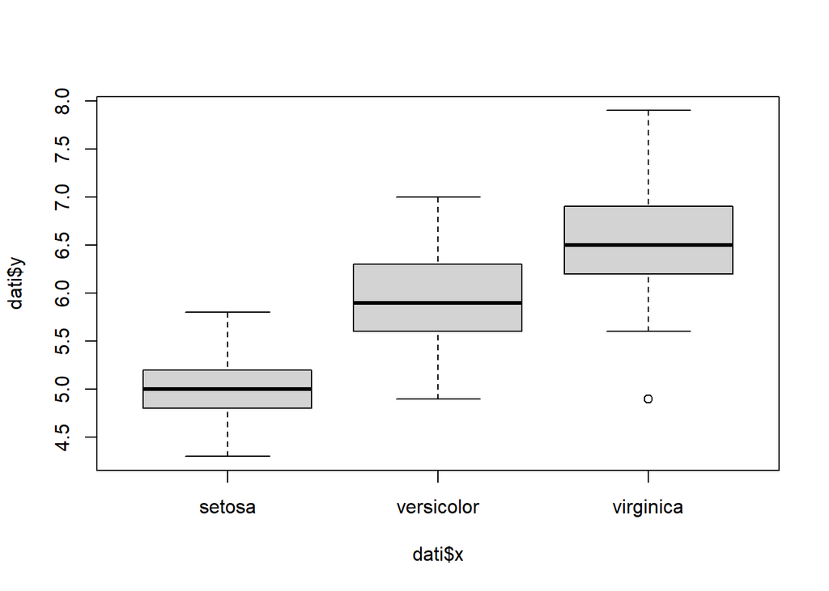

```r
plot(dati$y ~ dati$x)
```

Gli stami sono tre e il pistillo è unico, con ovario infero sormontato da un corto stilo filamentoso, che porta tre stimmi simili a petali di colore giallo; il frutto si presenta come una capsula a sezione triangolare lunga 4–5 cm, leggermente acuminata e con numerosi semi.

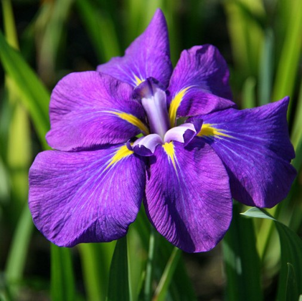

iris viola

# Altro iris

Gli iris originari dell’Europa come l’I. germanica vegetano su qualunque suolo, anche arido, preferendo terreni soffici, sciolti, ben drenati e fertili, esposizione in pieno sole.

- Le specie esotiche sensibili al gelo richiedono luoghi ombrosi,
  - terreno di medio impasto, fresco, vicino a bacini d’acqua,
  - cure particolari, con un periodo di assoluto riposo vegetativo dalla fine della fioritura (fino all’autunno, Bruner 1985), per ottenere buone fioriture nella stagione successiva.

```
NA   Sepal.Length    Sepal.Width     Petal.Length    Petal.Width
NA  Min.   :4.300   Min.   :2.000   Min.   :1.000   Min.   :0.100
NA  1st Qu.:5.100   1st Qu.:2.800   1st Qu.:1.600   1st Qu.:0.300
NA  Median :5.800   Median :3.000   Median :4.350   Median :1.300
NA  Mean   :5.843   Mean   :3.057   Mean   :3.758   Mean   :1.199
NA  3rd Qu.:6.400   3rd Qu.:3.300   3rd Qu.:5.100   3rd Qu.:1.800
NA  Max.   :7.900   Max.   :4.400   Max.   :6.900   Max.   :2.500
NA        Species         y                  x
NA  setosa    :50   Min.   :4.300   setosa    :50
NA  versicolor:50   1st Qu.:5.100   versicolor:50
NA  virginica :50   Median :5.800   virginica :50
NA                  Mean   :5.843
NA                  3rd Qu.:6.400
NA                  Max.   :7.900
```

Uno dei più importanti scrittori greci antichi fu Eracleide, che descrisse alcune ricette, riprese in seguito da Aulo Cornelio Celso (Epifania, Anselmi, and Robusto 2020a). Le radici studiate e messe in vendita vennero definite “farmacopoli” e si basavano soprattutto su nozioni tratte dai testi di Ippocrate di Coo e sugli scritti di botanica di Teofrasto.

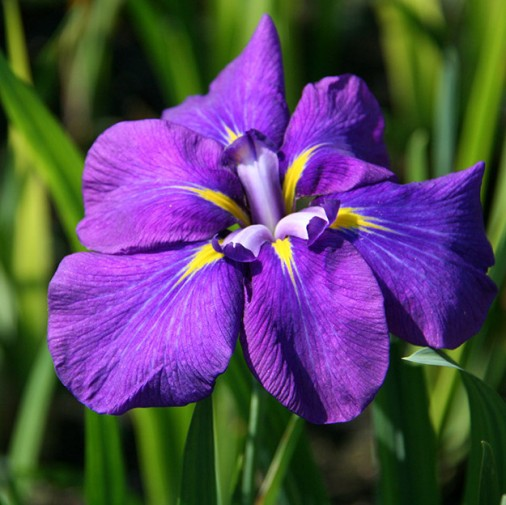

Iris violino

```r
knitr::include_graphics(path = "img/Iris-kaempferi-Viola-Giaggiolo-2.jpg")
```

|  | Sepal.Length | Sepal.Width | Petal.Length | Petal.Width | Species | y | x |
| --- | --- | --- | --- | --- | --- | --- | --- |
| 1 | 5.1 | 3.5 | 1.4 | 0.2 | setosa | 5.1 | setosa |
| 2 | 4.9 | 3.0 | 1.4 | 0.2 | setosa | 4.9 | setosa |
| 3 | 4.7 | 3.2 | 1.3 | 0.2 | setosa | 4.7 | setosa |
| 4 | 4.6 | 3.1 | 1.5 | 0.2 | setosa | 4.6 | setosa |
| 5 | 5.0 | 3.6 | 1.4 | 0.2 | setosa | 5.0 | setosa |
| 6 | 5.4 | 3.9 | 1.7 | 0.4 | setosa | 5.4 | setosa |

Gli arabi diedero un grande impulso all’alchimia medievale, principalmente per lo sviluppo farmaceutico di tinture e di distillati. Gli arabi (Epifania, Anselmi, and Robusto 2020b) furono i primi a tentare di organizzare la farmacopea: crearono un elenco di ricette descrivendo le proporzioni e le composizioni chimiche. Al XI secolo risalgono i primi testi farmaceutici, in cui confluirono le influenze greche, romane e arabe, sintetizzate nella definizione delle operazioni fondamentali:

- lozione,
- decozione,
- infusione e triturazione.

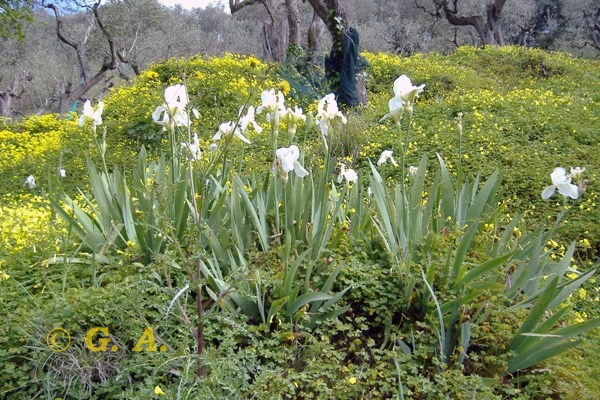

Iris bianco

```r
knitr::include_graphics(path = "img/iris_albicans (3).jpg")
```

In questo periodo si diffuse l’uso delle spezie e delle droghe e la Scuola Medica Salernitana introdusse assieme alle pratiche chirurgiche anche una forma molto primitiva di anestesia, la cosiddetta spongia sonnifera. La Scuola salernitana per l’epoca una aveva buona capacità di selezionare le erbe.

Nel 1533, a Padova, fu istituita la prima cattedra di “botanica sperimentale”

- Mattioli redasse nel 1554 il più significativo tra i testi di botanica dell’epoca, che veniva ritenuto anche testo di medicina.
  1. Nel Seicento, Pierre Magnol inserì nella classificazione le famiglie tassonomiche, suddividendo il mondo vegetale in settantasei gruppi.
- Nel secolo successivo, la spinta maggiore per il progresso della botanica avvenne grazie allo svedese Carl von Linné. Egli identificò le specie viventi, dividendole in classi, quindi in ordini e infine in generi.

> I sistemi botanici attuali stanno infine basando finalmente la loro veridicità sull’analisi del DNA.

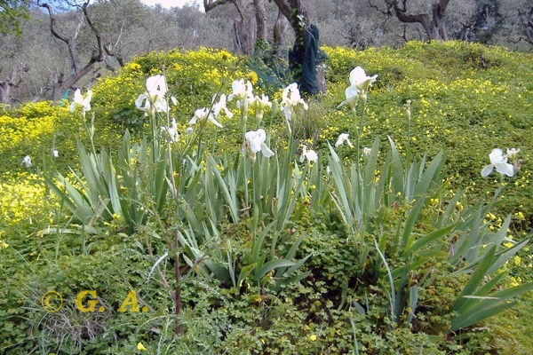

Iris bianco

```r
knitr::include_graphics(path = "img/iris_albicans (3).jpg")
```

# Ultimo iris

è nativa dell’area della Cina [^2]

```r
iris
```

| Sepal.Length | Sepal.Width | Petal.Length | Petal.Width | Species |
| --- | --- | --- | --- | --- |
| 5.1 | 3.5 | 1.4 | 0.2 | setosa |
| 4.9 | 3.0 | 1.4 | 0.2 | setosa |
| 4.7 | 3.2 | 1.3 | 0.2 | setosa |
| 4.6 | 3.1 | 1.5 | 0.2 | setosa |
| 5.0 | 3.6 | 1.4 | 0.2 | setosa |
| 5.4 | 3.9 | 1.7 | 0.4 | setosa |
| 4.6 | 3.4 | 1.4 | 0.3 | setosa |
| 5.0 | 3.4 | 1.5 | 0.2 | setosa |
| 4.4 | 2.9 | 1.4 | 0.2 | setosa |
| 4.9 | 3.1 | 1.5 | 0.1 | setosa |

[output cut: 140 more lines]

```r
library("stargazer")
m = lm(y ~ x, data = dati)
stargazer(dati, type="latex", summary = TRUE,
           title= "Tabella di summary", digits = 2, header=FALSE)
```

[output not shown]

```r
library(stargazer)
stargazer(m, type = "latex", summary = TRUE, title = "Risultati del modello", digits = 2, header = FALSE)
```

[output not shown]

$$z_i=\dfrac{x_i-\bar{X}}{sd}$$

```r
(dati$y[1]-mean(dati$y))/sd(dati$y)
```

```
## [1] -0.8976739
```

$$z_i=\frac{-0.7433333}{0.8280661}$$
$$z_i=\dfrac{x_i-\bar{X}}{sd} =
\frac{-0.7433333}{0.8280661} = -0.8976739$$

# References

Bruner, Jerome. 1985. “Child’s Talk: Learning to Use Language.” *Child Language Teaching and Therapy* 1 (1): 111–14.

Epifania, Ottavia M, Pasquale Anselmi, and Egidio Robusto. 2020a. “Dscoreapp: A Shiny Web Application for the Computation of the Implicit Association Test d-Score.” *Frontiers in Psychology* 10: 489006.

———. 2020b. “Implicit Measures with Reproducible Results: The implicitMeasures Package.” *Journal of Open Source Software* 5 (52): 2394.

[^1]: alberello alberoso alberino violetto
[^2]: nazione dell’Oriente